# AI Innovation Efficiency Dashboard

**Overview**

In the current global economy, Artificial Intelligence (AI) has become a primary driver of industrial transformation. According to the 2024 AI Index Report from Stanford University, corporate investment in AI has reached a critical juncture where the scale of spending does not always guarantee a proportional output in innovation. This project explores how corporate R&D investment translates into tangible AI outcomes, specifically through patent filings, which serve as a proxy for protected technological advancement.

We focus on answering three big picture questions:

🔍 **RQ1:** How does AI patenting efficiency differ across R&D intensity groups?

🏭 **RQ2:** Which sectors show the highest AI patenting efficiency?

📈 **RQ3:** Does efficiency rise or fall as R&D intensity increases?

Analyzing these questions is critical for understanding the “return on investment” (ROI) of innovation. By identifying which sectors or investment levels are most efficient, we can provide insights into the competitive landscape of the AI era.

**Ethical Considerations**: Using patent data presents certain limitations. Patents often favor large corporations with extensive legal departments, which might overlook the contributions of open-source communities or smaller startups that do not prioritize intellectual property protection. Furthermore, our dataset primarily focuses on the “Top 2000” global investors, which potentially biases our findings toward established economic powers and ignores emerging markets.

**Quick Summary**: This dashboard visualizes the “Efficiency” of AI innovation, defined as the number of AI patents produced per €1B of R&D spending.

📊 Dataset 1: Private-Sector AI Indicators **Source:** [CSET, Georgetown University](https://eto.tech/dataset-docs/private-sector-ai-indicators/)

The Center for Security and Emerging Technology (CSET) at Georgetown University produced this dataset to measure AI innovation through corporate research publications and patent filings. This sample includes 692 notable companies that are actively engaged in the AI ecosystem, with data points spanning from 2010 to 2024. By utilizing AI-specific topic classification methods, the researchers were able to filter general tech data into a refined set of AI indicators. However, a potential shortcoming of this sample is “visibility bias,” as it primarily captures firms that actively publish or file patents, potentially overlooking smaller startups or companies that keep their AI research as trade secrets. This dataset allows us to see how companies in different countries prioritize AI research intensity relative to their size.

| Name | Country | Patents..AI.patents | clean_name | core_id |
| --- | --- | --- | --- | --- |
| Accenture | Ireland | 494 | ACCENTURE | 1 |
| Cognizant | United States | 83 | COGNIZANT | 2 |
| Amazon | United States | 1988 | AMAZON | 3 |
| IBM | United States | 9135 | IBM | 4 |
| Microsoft | United States | 4146 | MICROSOFT | 5 |
| Alphabet (including Google) | United States | 4387 | ALPHABET (INCLUDING GOOGLE) | 6 |
| Oracle | United States | 441 | ORACLE | 7 |
| Deloitte Touche Tohmatsu | United Kingdom | 7 | DELOITTE TOUCHE TOHMATSU | 8 |
| Apple | United States | 787 | APPLE | 9 |
| Cisco Systems | United States | 906 | CISCO SYSTEMS | 10 |

💰 Dataset 2: EU Industrial R&D Scoreboard **Source:** [European Commission, JRC](https://iri.jrc.ec.europa.eu/scoreboard/2025-eu-industrial-rd-investment-scoreboard)

The second dataset is the 2025 edition of the EU Industrial R&D Investment Scoreboard, which reports the financial and innovation performance of the world’s top 2000 corporate R&D investors. The data are compiled by the European Commission’s Joint Research Centre (JRC) from audited annual financial reports, ensuring a high level of accuracy for total R&D expenditure in millions of euros. Since this dataset reflects fiscal year 2024 data, it provides the most current record of corporate investment behavior across various industrial sectors and geographic regions. A significant limitation of this sample is that it only represents the “population” of the largest global investors, meaning the R&D trends of small-to-medium enterprises (SMEs) are not fully reflected in our efficiency analysis. We use this data to provide the “input” side (spending) of our innovation efficiency equation.

Source Link: EU Industrial R&D Investment Scoreboard – World 2000 Edition European Commission, Joint Research Centre (JRC) https://iri.jrc.ec.europa.eu/scoreboard/2025-eu-industrial-rd-investment-scoreboard

| Company | R&D (€million) | R&D intensity (%) | ICB3 short | clean_name |
| --- | --- | --- | --- | --- |
| AMAZON.COM, INC. | 65318.28 | 10.636916 | ICT services | AMAZON.COM, . |
| ALPHABET INC. | 46131.49 | 13.692439 | ICT services | ALPHABET . |
| META PLATFORMS, INC. | 41985.75 | 26.515948 | ICT services | META PLATFORMS, . |
| MICROSOFT CORPORATION | 31271.54 | 11.531854 | ICT services | MICROSOFT |
| APPLE INC. | 30195.40 | 8.022300 | ICT producers | APPLE . |
| HUAWEI INVESTMENT & HOLDING CO., LTD. | 22941.20 | 20.180449 | ICT producers | HUAWEI INVESTMENT & HOLDING ., . |
| SAMSUNG ELECTRONICS CO.,LTD. | 22842.50 | 11.632279 | ICT producers | SAMSUNG ELECTRONICS .,. |
| VOLKSWAGEN AG | 20998.00 | 6.467769 | Automobiles & Parts | VOLKSWAGEN AG |
| JOHNSON & JOHNSON | 16586.77 | 19.400817 | Health industries | JOHNSON & JOHNSON |
| INTEL CORP | 15926.46 | 31.159488 | ICT producers | INTEL |

| Company | R&D (€million) | R&D intensity (%) | ICB3 short | clean_name.x | core_id | Name | Country | Patents..AI.patents | clean_name.y |
| --- | --- | --- | --- | --- | --- | --- | --- | --- | --- |
| MICROSOFT CORPORATION | 31271.537 | 11.531854 | ICT services | MICROSOFT | 5 | Microsoft | United States | 4146 | MICROSOFT |
| APPLE INC. | 30195.399 | 8.022300 | ICT producers | APPLE . | 9 | Apple | United States | 787 | APPLE |
| VOLKSWAGEN AG | 20998.000 | 6.467769 | Automobiles & Parts | VOLKSWAGEN AG | 425 | Volkswagen | Germany | 36 | VOLKSWAGEN |
| JOHNSON & JOHNSON | 16586.774 | 19.400817 | Health industries | JOHNSON & JOHNSON | 98 | Johnson & Johnson | United States | 275 | JOHNSON & JOHNSON |
| INTEL CORP | 15926.461 | 31.159488 | ICT producers | INTEL | 13 | Intel | United States | 2191 | INTEL |
| NVIDIA CORP | 12430.455 | 9.896013 | ICT producers | NVIDIA | 31 | Nvidia | United States | 1457 | NVIDIA |
| ASTRAZENECA PLC | 12032.919 | 23.118747 | Health industries | ASTRAZENECA | 131 | Astrazeneca | United Kingdom | 24 | ASTRAZENECA |
| ELI LILLY AND COMPANY | 10579.074 | 24.400402 | Health industries | ELI LILLY AND | 165 | Eli Lilly And Company | United States | 7 | ELI LILLY AND |
| PFIZER INC | 10335.932 | 16.876483 | Health industries | PFIZER | 150 | Pfizer | United States | 13 | PFIZER |
| ORACLE CORP | 9490.808 | 17.178000 | ICT services | ORACLE | 7 | Oracle | United States | 441 | ORACLE |

Justification for Data Selection: We selected datasets from CSET (Georgetown University) and the European Commission (JRC) due to their high institutional authority and rigorous data collection methodologies. The CSET dataset provides granular, AI-specific indicators that are not available in general financial databases, while the EU Scoreboard offers audited financial figures for the world’s top 2000 R&D investors. By combining these two, we ensure that our analysis is grounded in verified corporate spending and specialized innovation output, minimizing the risk of “greenwashing” or self-reported bias.

Justification for Fuzzy Matching: A standard left_join requires an exact character-for-character match between company names. However, corporate names often vary across global databases due to inconsistent use of legal suffixes (e.g., “Apple Inc” vs. “Apple Corp” or “Microsoft” vs. “Microsoft Corporation”). To prevent significant data loss, we implement Fuzzy Matching using the stringdist package. By calculating the Levenshtein distance between strings, we can successfully link entities that are semantically identical but syntactically different, increasing our sample size and the robustness of our cross-dataset analysis.

Justification for Data Standardization: Raw patent counts are heavily biased toward giant multinational corporations with massive R&D budgets. To ensure a “fair” comparison between industry titans and highly innovative mid-sized firms, we perform Standardization by calculating AI Patent Efficiency. By dividing the total AI patents by the R&D investment (normalized per €1 Billion), we create a relative performance metric. This allows us to identify “efficiency leaders”—companies that produce the highest innovation output per unit of financial input, regardless of their absolute size.

**RQ1 — Boxplot: AI Patenting Efficiency by R&D Intensity**

AI Patenting Efficiency by R&D Intensity Group

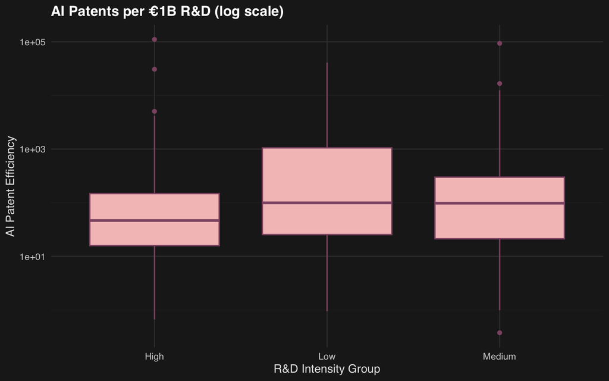

```r
ggplot(final_wrangle |> filter(AI_Patent_Eff_1B > 0),
       aes(x = RD_Intensity_Group, y = AI_Patent_Eff_1B)) +
  geom_boxplot(
    fill = "#F4C2C2",
    color = "#8E5572",
    linewidth = 0.6
  ) +
  scale_y_log10() +
  labs(
    title = "AI Patents per €1B R&D (log scale)",
    x = "R&D Intensity Group",
    y = "AI Patent Efficiency"
  ) +
  theme_dark_custom()
```

Interpretation — RQ1 The distribution of AI patent efficiency varies widely across R&D intensity groups.

This pattern supports the idea that efficiency does not scale linearly with investment.

**RQ2 — Sector Ranking Bar Chart**

Average AI Patent Efficiency by Sector

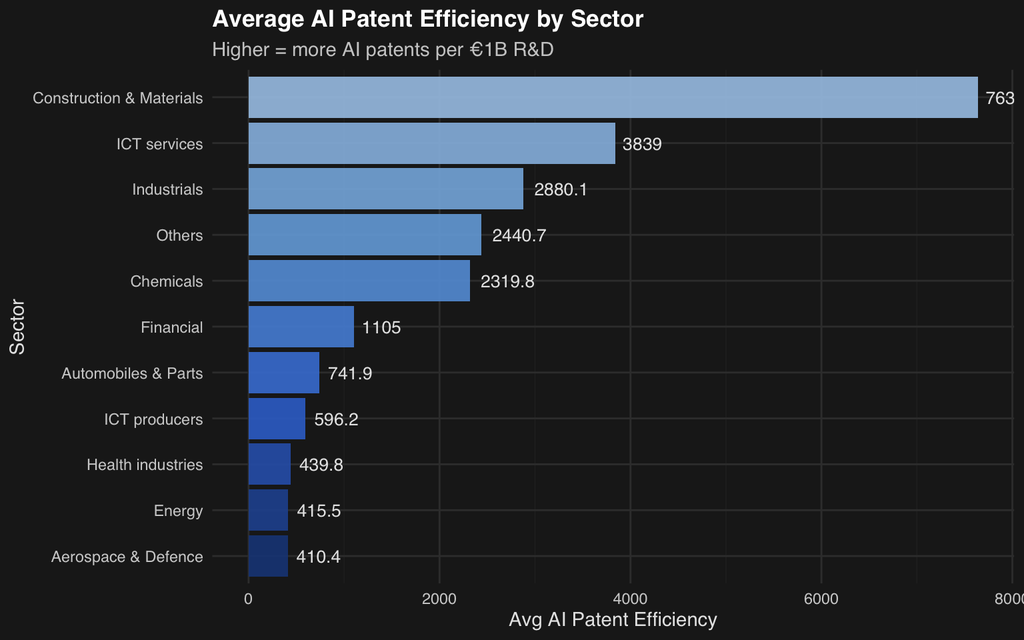

```r
sector_summary <- final_wrangle |>
  group_by(Sector) |>
  summarize(
    mean_eff = mean(AI_Patent_Eff_1B, na.rm = TRUE),
    company_count = n()
  ) |>
  arrange(desc(mean_eff)) |>
  mutate(Sector = factor(Sector, levels = Sector))

ggplot(sector_summary,
       aes(x = reorder(Sector, mean_eff), y = mean_eff, fill = Sector)) +
  geom_col(alpha = 0.9) +
  scale_fill_manual(values = blue_palette) +
  geom_text(aes(label = round(mean_eff, 1)),
            hjust = -0.2, size = 3.5, color = "#E6E6E6") +
  coord_flip() +
  labs(
    title = "Average AI Patent Efficiency by Sector",
    subtitle = "Higher = more AI patents per €1B R&D",
    x = "Sector",
    y = "Avg AI Patent Efficiency"
  ) +
  theme_dark_custom() +
  theme(legend.position = "none")
```

Interpretation — RQ2

Sectors differ substantially in their ability to generate AI patents per €1B of R&D.

The ranking highlights how sectoral characteristics shape innovation productivity.

**RQ3 — Trend Line Across R&D Intensity**

Trend of AI Patent Efficiency Across R&D Intensity Levels

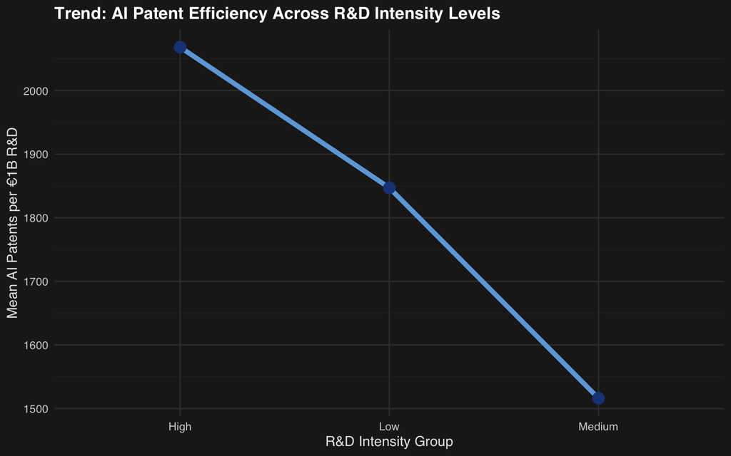

```r
trend_df <- final_wrangle |>
  group_by(RD_Intensity_Group) |>
  summarize(mean_eff = mean(AI_Patent_Eff_1B, na.rm = TRUE))

ggplot(trend_df, aes(x = RD_Intensity_Group, y = mean_eff, group = 1)) +
  geom_line(color = "#6FA8DC", linewidth = 1.8) +
  geom_point(size = 4, color = "#1C4587") +
  labs(
    title = "Trend: AI Patent Efficiency Across R&D Intensity Levels",
    x = "R&D Intensity Group",
    y = "Mean AI Patents per €1B R&D"
  ) +
  theme_dark_custom()
```

Interpretation — RQ3 (Trend Line)

The trend line reveals a non-linear relationship between R&D intensity and AI patent efficiency.

**RQ3 — Bar chart: AI Patent Efficiency by R&D Intensity Group**

Average AI Patent Efficiency by R&D Intensity Group

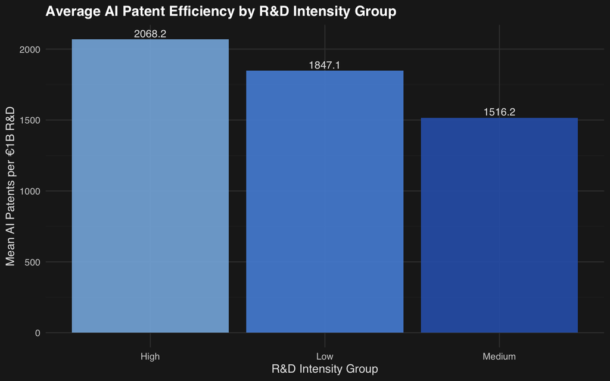

```r
trend_df <- final_wrangle |>
  group_by(RD_Intensity_Group) |>
  summarize(mean_eff = mean(AI_Patent_Eff_1B, na.rm = TRUE))

ggplot(trend_df,
       aes(x = RD_Intensity_Group, y = mean_eff, fill = RD_Intensity_Group)) +
  geom_col(alpha = 0.9) +
  scale_fill_manual(values = blue_palette[ c(3, 6, 9) ]) +
  geom_text(aes(label = round(mean_eff, 1)),
            vjust = -0.3, size = 3.5, color = "#E6E6E6") +
  labs(
    title = "Average AI Patent Efficiency by R&D Intensity Group",
    x = "R&D Intensity Group",
    y = "Mean AI Patents per €1B R&D"
  ) +
  theme_dark_custom() +
  theme(legend.position = "none")
```

Interpretation — RQ3 (Bar Chart)

This reinforces the idea that strategic allocation—not absolute spending—is key to maximizing innovation ROI.

**Maps**

```r
library(plotly)
library(dplyr)

country_eff <- final_wrangle |>
  group_by(Country) |>
  summarize(mean_eff = mean(AI_Patent_Eff_1B, na.rm = TRUE))

plot_ly(
  country_eff,
  type = "choropleth",
  locations = ~Country,
  locationmode = "country names",
  z = ~mean_eff,
  colorscale = list(
    c(0, "#A7C7E7"),   # light blue
    c(1, "#1C4587")    # deep blue
  ),
  marker = list(line = list(color = "#1e1e1e"))
) |>
  layout(
    title = list(
      text = "AI Patent Efficiency by Country",
      font = list(color = "#E0E0E0")
    ),
    geo = list(
      bgcolor = "#1e1e1e",
      lakecolor = "#1e1e1e",
      landcolor = "#2a2a2a",
      showlakes = TRUE,
      showland = TRUE,
      projection = list(type = "natural earth")
    ),
    paper_bgcolor = "#1e1e1e",
    plot_bgcolor = "#1e1e1e",
    font = list(color = "#E0E0E0")
  )
```

[interactive chart not shown]

Interpretation — Country Map

The geographic distribution of AI patent efficiency shows strong regional clustering.

Countries with established innovation ecosystems—such as the United States, South Korea, and parts of Western Europe—exhibit higher efficiency levels.

Emerging economies show more variability, reflecting differences in national R&D infrastructure and patenting culture.

The map highlights how local innovation environments influence corporate R&D outcomes.

👤 **Team Member: Duofei Cui**

**Role:** Data Visualization & Lead Developer  
**Contributions:** * Developed the custom `theme_dark_custom` and color palettes. * Implemented the interactive Plotly map and sector-specific bar charts. * Managed data joining logic using the `stringdist` fuzzy matching algorithm.

**Contact:** duofec@uw.edu

👤 **Team Member: Carol Zeng**

**Role:** Data Research & Statistical Analysis  
**Contributions:** * Sourced and cleaned datasets from CSET and the EU Industrial R&D Scoreboard. * Defined the research questions and R&D intensity grouping logic. * Conducted the trend analysis for AI Patent Efficiency (RQ3).

**Contact:** hxz63@uw.edu

📊 **Project Overview**

This dashboard is the final project for **INFO 201**. Our goal was to investigate the relationship between corporate R&D investment and AI patenting output. By merging global financial data with AI-specific patent metrics, we aim to identify which sectors and intensity levels are the most “efficient” at generating AI innovation.

🔗 **Resources & Links**

- **GitHub Repository:** [View Source Code](https://github.com/Carolzhxxx/Carolzhxxx.github.io)
- **Data Source 1:** [CSET Private-Sector AI Indicators](https://eto.tech/dataset-docs/private-sector-ai-indicators/)
- **Data Source 2:** [EU Industrial R&D Investment Scoreboard](https://iri.jrc.ec.europa.eu/scoreboard/2025-eu-industrial-rd-investment-scoreboard)
- **Tools Used:** R (dplyr, ggplot2, plotly, stringdist), Quarto Dashboards.

*Created in Winter 2025 for INFO 201.*